# Brief Tutorial on Documentation in R

A # followed by text becomes your title!

# 1 Brief tutorial on R Manrkdown

Optional YAML metadata resides between two tripple dashes: `---`

Section begins by two hashes: ##

## 1.1 Section 1

This is goign to be a first document.

How do we include an R code in this doc? Well just press: Ctrl-Alt-I and a code separator (three back ticks: ```) will appear!

```r
require(dplyr);
ns = dplyr::nasa;
ns = as.data.frame(ns);
mean_lat = mean(ns$lat, na.rm = T);
mean_lat
```

```
## [1] 7.5
```

But I dont want to see all these messages in my doc. I am going to run the above with option: `include = FALSE`

See nothing got printed above!

But I do want to display the output but not the code! Use `echo = FALSE` instead.

```
## [1] 7.5
```

Now only the output got printed. This is what I really wanted!

What if I wanted to dynamically use a value in my doc? Like generated from a computation? We can do that by writing within backticks with first letter being `r`. So mean latitude is 7.5. This makes it very easy to update report in future with minimal changes. Lets write counting from 1 to 10: 1, 2, 3, 4, 5, 6, 7, 8, 9, 10

Now, let’s make a plot!

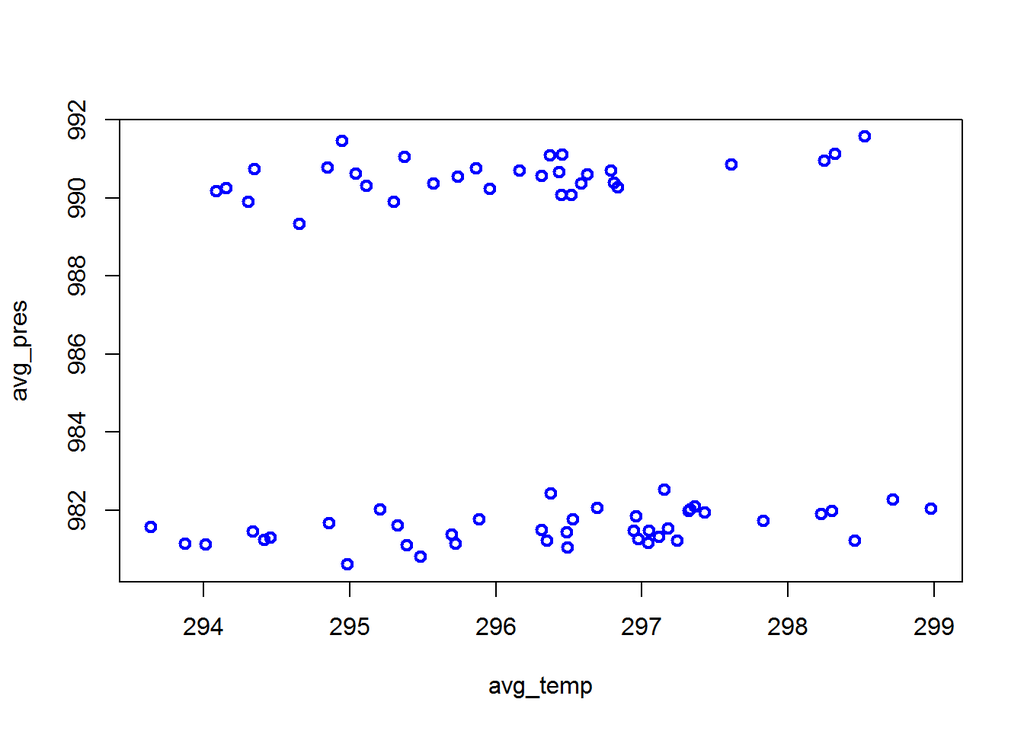

The plot here is a bit too big. I would like a smaller one for my doc:

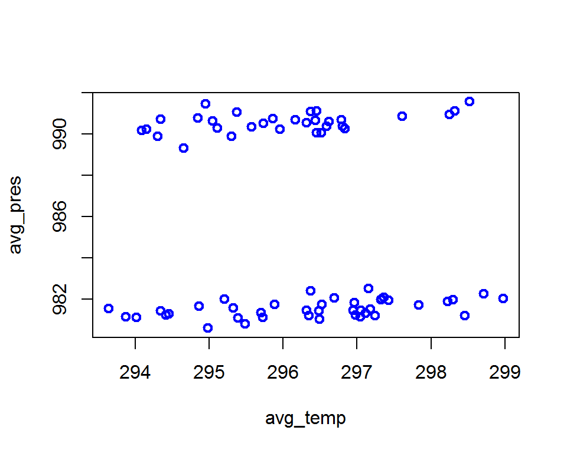

avg pressure vs avg temp

See the above fits much better!

## 1.2 Section 2

To get code within the doc (in teletype constant width fonts), use single backtics: `code`, Package `dplyr`

Block quote begins with `>` sign:

> This is a block quote!

Any text within a pair of `*` is `*italicized*`: *italicized* and within `**` is `**bolded**`: **bolded**

Single star followed by a space: `*` produces bullet points! 4 blank spaces, a star and then a space: `| * |` produces sub-itmes! It can be further generalized!

- 1
- 2
  - 2.1
  - 2.2
    - 2.2.1

## 1.3 Section 3

Math mode can be entered by writing everything within pair of dollar signs: `$`.

$F = m \cdot a$, $\lambda^2 \gamma$, $\infty$, and so on!

Write a block of equations using two dollar signs instead of one: `$$`.
$$\int e^x dx = e^x + C$$
.

Use underscore `_` for subscripts and exponent `^` for superscript. `H_0` is $H_0$ and `H^0` is $H^0$. Use curly brackets to combine parts of an equation, i.e. to write `lambda^(a+b)` as `\lambda^{a+b}`: $\lambda^{a+b}$

## 1.4 Section 4

Use extra hash `#` for sub-sectioning.

### 1.4.1 Sub-section 4.1

### 1.4.2 Sub-sub-section 4.1.1

### 1.4.3 Sub-sub-sub-section 4.1.1.1

### 1.4.4 Sub-sub-sub-sub-section 4.1.1.1.1

## 1.5 Section 5

To create a document, a process called knitting, you can simply click to knit on Rmarkdown interface. Or, you can incoke the command line: `rmarkdown::render("first_doc.Rmd")`

## 1.6 Section 6

Hyperlink can be added by writing text within braces `[]` followed by the weblink written within parantheses `()`. Thus you write like: `[Google](https://www.google.com/)` to get [Google](https://www.google.com/).

Footnote can be added by `[^1]`. Here is one.[^1]

You can also add a reference using `[@bib_ref]`. For instance I’ll make a reference here: (Baumer et al. 2014). Also don’t forget to add a section on References and mention the `.bib` file in YAML metadata.

## 1.8 Section 8

Let’s make table:

Your Caption

| First Header | Second Header | Third Header |
| --- | --- | --- |
| First row | Data | Very long data entry |
| Second row | **Cell** | *Cell* |
| Third row | Cell that spans across two columns |  |

## 1.9 Section 9

$$\begin{equation}
a=b^2
\end{equation}$$

# References

Baumer, Ben, Mine Cetinkaya-Rundel, Andrew Bray, Linda Loi, and Nicholas J Horton. 2014. “R Markdown: Integrating a Reproducible Analysis Tool into Introductory Statistics.” *ArXiv Preprint ArXiv:1402.1894*.

[^1]: That’s my foot note!